# Inference 1 - Estimation, Bias and Confidence Intervals

## Contents and Goals

Using our knowledge of random variables and their properties, we are now able to conduct some basic inference. This means that we can utilise the *information from a random sample* of i.i.d. variables to learn something about the *population* of these variables.

In this part we're going to:

- Learn what an estimator is
- Take a a look at the properties of our estimators
- Derive properties of our estimators
- Bias / Unbiasedness
- Sampling Distribution
- Introduce Interval Estimation

## Simulated Population

Let's look at an example. Suppose know the population of ZU students income:

```r
set.seed(11) # seed for reproducibility

n <- 1200
inc <- rnorm(n, mean = 1000, sd = 200)

print(inc[1:50])
```

```
##  [1]  881.7938 1005.3189  696.6894  727.4693 1235.6978  813.1697 1264.7211
##  [8] 1124.9836  990.8554  799.1759  834.3134  930.3297  692.3413  948.8870
## [15]  770.0110 1002.4654  955.4061 1177.5543  881.5689  868.8564  863.4965
## [22]  996.8284  911.4790 1070.5115 1014.6341 1001.4318  962.4800  846.8599
## [29]  955.7886  803.2823  779.1432  812.3700 1135.7248  684.5004  826.0123
## [36] 1096.9354  962.7895 1309.1109  877.7240  930.4487  672.6967 1004.0763
## [43] 1178.3485  825.4501 1178.0102  931.2251  562.6437 1176.0116 1144.7713
## [50] 1043.9705
```

## Simulated Population

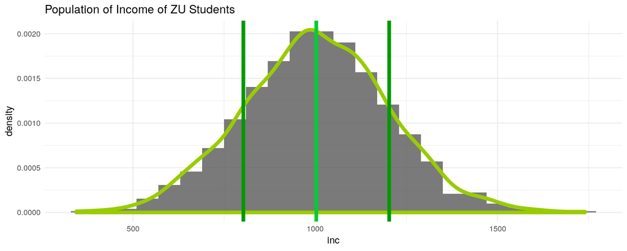

- Population mean: \(\mu_{inc} = 1000\)
- Population standard deviation: \(\sigma_{inc} = 200\)

## Simulated Population

Since we have simulated the population, we are in a position where we know:

- The true population mean \(\mu_{inc} = 1000€\)
- The true population variance \(\sigma_{inc}^2\) and standard deviation \(\sigma_{inc} = 200\)
- The distribution of inc: \(inc \sim N(\mu_{inc},\sigma_{inc})\)

Suppose now we are interested in the mean of the population (the green line). Given a sample from this distribution, our task now is to estimate the population mean as good as we can.

## Introducing Estimators

Often we don't have knowledge of our population, but have a sample.

From these samples, we can derive knowledge about our population. E.g. its basic moments: the mean and the variance.

Using a sample to derive a moment (or parameter) is called **Estimation**

Generally:

- If we have a random sample \({X_1, \dots, X_n}\),
- from a population that depends on some parameter \(\theta\)
- an estimator \(W = f(X)\) is a rule to calculate a certain value
- for *each* possible outcome of the sample

E.g. we can estimate the parameter \(\mu\) by calculating the arithemtic mean from a sample.

## Estimating the First Moment / Expected Value

Given a random sample \(\{X_1, X_2, \dots, X_n\}\) we can calculate the **sample mean** by:

\[ \bar{X} = \frac{1}{n} \sum_{i=1}^n X_i \qquad \text{sample estimator for } \mu_{inc}\]

which is also known as the *arithmetic mean*. Let's simulate a random sample from our ZU students income:

```r
set.seed(24)
sample_1 <- sample(x = inc, size = 50, replace = F)
print(sample_1[1:10])
```

```
##  [1]  955.7316 1244.9077  950.9362 1218.1390 1248.7526 1084.4991 1017.5970
##  [8]  954.1157  637.2859 1413.1001
```

## Estimating the First Moment / Expected Value

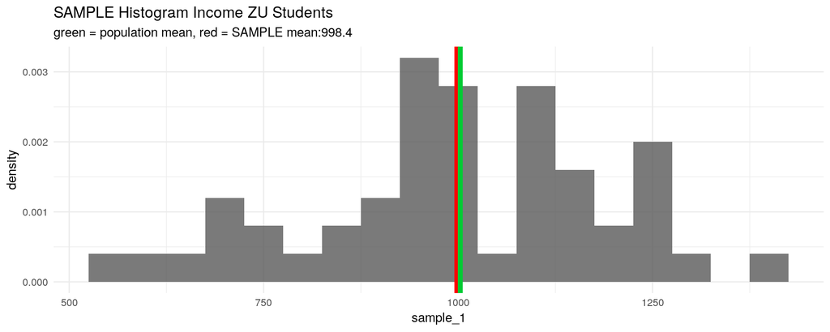

But how can we draw an inference about the **population mean** \(\mu_X\) from this? It could well be that our proposed \(\bar{X}\) is a very bad estimator for \(\mu_X\).

## Introducing Unbiasedness

- We can analyse many samples of ZU student income
- If our estimator \(\bar{X}\) is any good, it should predict the true mean if we do that

Formally, we call this *unbiasedness*:

- **the estimator derived from a random sample predicts the population parameter on average.**

\[ \mathbb{E}[\bar{X}] = \mu_X \]

Or, in other words: our estimator \(\bar{X}\) ist distributed with mean \(\mu_X\).

The bias of our estimator is then given by: \[ \begin{aligned} Bias[\bar{X}] &= \mathbb{E}[\bar{X}] - \mu_X \\ &= 0 & \text{if the estimator is unbiased} \end{aligned} \]

## Introducing Unbiasedness

So if \(\mathbb{E}[\bar{X}]\) is equal to \(\mu_X\), our arithmetic mean would be unbiased. Lets prove this:

\[ \text{ See whiteboard. The proof will be procided in the script} \]

## Introducing the Sampling Variance

- Another feature of distributions is their variance
- The variance **of the mean of** the sample (not *of the sample*) is called *sampling variance*

\[ Var[\bar{X}] = \frac{\sigma_X^2}{n} \]

The proof of this is very similar to the proof for the sample mean.

The sampling standard deviation is then given by: \[ sd[\bar{X}] = \frac{\sigma_X}{\sqrt{n}} \]

## The Distribution of our Estimator

- We know now now the expected value and the sampling variance of our estimator \(\bar{X}\):

\[ \mathbb{E}[\bar{inc}] = \mu_{inc} = 1000 \] \[sd[\bar{inc}]= \frac{\sigma_{inc}}{\sqrt{n}} = \frac{200}{\sqrt{50}} = 28.28\]

- Since \(\bar{X}\) is a linear function of normally distributed variables, it is also distributed normally.

## The Distribution of our Estimator

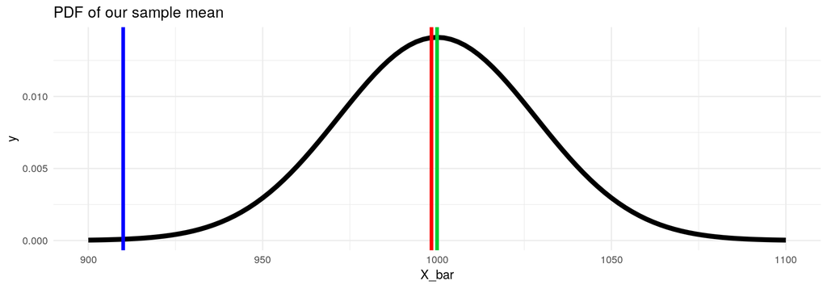

- Observing a mean ZU student income of \(\bar{X} = 998.4€\) from a random sample seems to be very likely
- A mean income of \(910€\) (blue line), is observed less often. Maybe the sample was from another (not private) university? ;)

## Short Recap

**What have we learned so far?**

- We can use a function of observations from a sample to estimate parameters from the population
  - E.g. we can use a function like \(\sum_{i=1}^n X_i\) to estimate \(\mu_X\)
- These estimators have a distribution. If the expected value of the estimator is equal to the estimated parameter, we call it *unbiased*
  - E.g. if \(\mathbb{E}[\bar{X}] = \mu_X + 50€\) we would overestimate ZU student income
- If we know the population standard deviation \(\sigma\), we can calculate the sampling variation of our estimator and tell how likely the sample is from the population

## Interval estimation

- Given the sampling variance and expected value of the estimator, we can also standardise it:

\[ Z= \frac{X - \mu_X}{\sigma_X} \qquad \text{general z-standardisation formula} \] \[ Z_{\bar{inc}} = \frac{\bar{inc} - \mu_{inc}}{\sigma_{inc} / \sqrt{n}} = \frac{998.4 -1000}{28.28} = - 0.056\]

- This helps us to calculate probabilities, since now our estimator is distributed *standard normally*

## Interval estimation

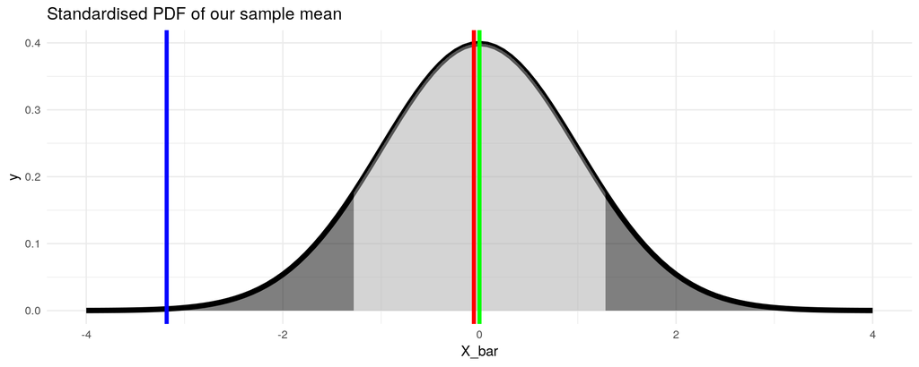

## Confidence Interval

We can also construct an interval around our sampled mean income \(\bar{inc}\) that contains \(\mu_{inc}\) with \(1- \alpha \%\) probability:

\[ \left[ \bar{x} - \frac{z_{1-\alpha/2}\sigma_X }{\sqrt{n}}, \bar{x} + \frac{z_{1-\alpha/2} \sigma_X }{\sqrt{n}} \right] \qquad \text{general confidence interval formula}\]

E.g. a \(95 \%\) confidence interval for our estimated ZU student income:

\[ \begin{aligned} \left[ 998.4 - \frac{1.96 *200 }{\sqrt{50}}, 998.4 + \frac{1.96 *200 }{\sqrt{50}} \right] &= [942.96,1053,84] \end{aligned}\]

## Confidence Interval

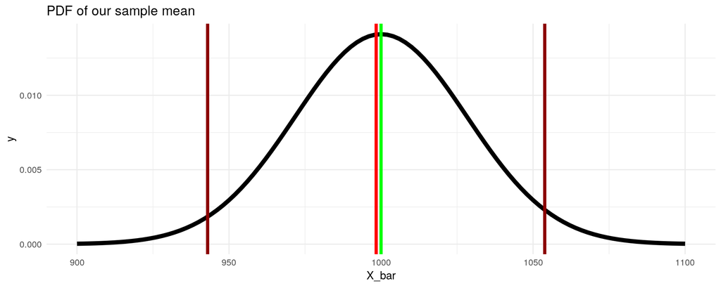

## Confidence Interval

But we could also observe in, \(5\%\) of cases, interval estimates that don't contain the true mean ZU student income:

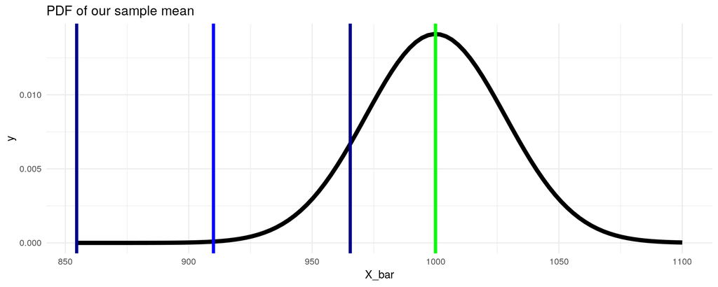

## Confidence intervals: The Whole Picture

If we take 500 samples and construct their confidence intervals for \(95\%\) we get:

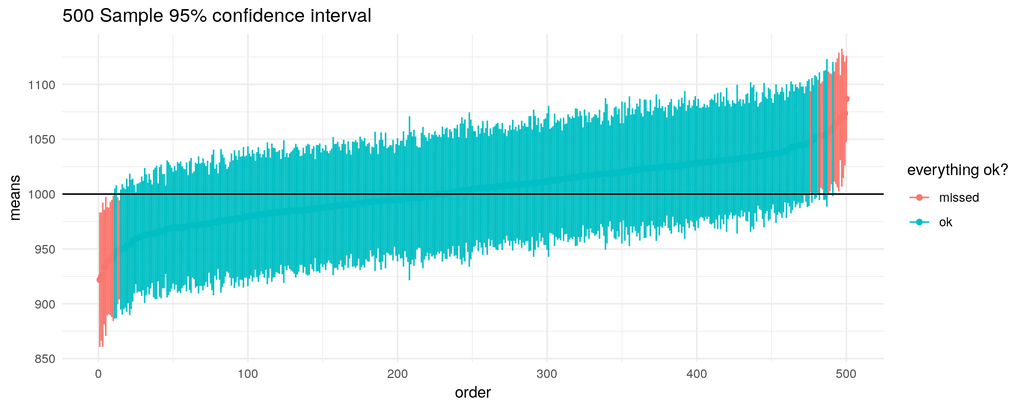

(Props to Marcel Schliebs for this visualisation)

## Estimating the Second Moment / Variance

\[ S^2 = \frac{1}{n-1} \sum_{i=1}^2 (X_i - \bar{X})^2 \]

- It is used when the population variance and standard devation are not known

We divide by \(\frac{1}{n-1}\) because we use \(\bar{X}\) and not \(\mu_X\). The details can be looked up [here](https://en.wikipedia.org/wiki/Variance#Sample_variance).

## Estimating the Second Moment / Variance

The sample standard deviation is given by: \[ S = \sqrt{S^2} \]

This estimator is not unbiased. However it is a *consistent* estimator for \(\sigma\) and we can still use it. For the sake of brevity we will skip the discussion of consistency here.

## Summary of Estimators and Bias

- Standardising our estimator helps us to calculate probabilities
  - In our case, \(\bar{X}\) became distributed standard normal after standardisation, because \(X\) is normal distributed
- We can easily look up z-values in a z-table or with `qnorm`
- We can construct confidence intervals around our estimates that are derived from our sampling procedure
  - The population parameter is contained within this intervail with a certain probability

## Excercises

- Go to (http://www.z-table.com/) and retrieve the z-values for the
  - \(10\%\), \(1 \%\) and \(0.1 \%\) quantiles
  - an interval that contains \(80 \%\) of the values under the standard normal pdf
- Retrieve the same values with the `qnorm()` function
- Construct a confidence interval for a sample with \(\bar{x} = 50\), \(\sigma_x = 5\) and size \(n=67\) that contains the true mean with \(80 \%\) probability